# Extension of the Group Response Outcome Over Time Method: Simulation Study

Summer Lab Rotation with Dr. Farrar (Work in progress)

Author

Long Khuong

Published

07-09-2024

```r
library(tidyverse)
library(mgcv)
library(splines)
library(survey)
```

# Overview

This simulation was conducted to propose some extension to the method of Group Response Outcome Over Time (GROOT) for longitudinal analyses of patient-level outcomes proposed by Ian DeLorey, John Farrar, et al (2024).

We organized the workflow into 3 main Sections:

- Section 1: to compare the statistical power of GROOT approach to the commonly used statistical models to analyze patient-reported outcomes.
- Section 2: to develope model-based GROOT and compare estimates to the non-parametric GROOT
- Section 3: to extend the model-based GROOT to account for confounders using causal inference approach (e.g., g-methods)

We did simulation in the context of pain research with the outcome evaluated using the Numeric Rating Scale (NRS), with the score ranging from 0 (no pain) to 10 (most intensive).

## Aim 1: Comparing power

In this section, we first simulate the the responses in the NRS scale in a parallel-group RCT with two arms: new drug (*“Treatment”*) compare to an active control (*“Control”*) , over the period of 24 hours. We assumed patients response to both treatments with *“typical curve”* with 3 phases: fast response, maintenance, and losing effect.

We then compared the power of non-parametric GROOT estimate with traditional longitudinal approaches of analyzing categorical responses. The statistical power was calculated as the proportion of time reaching statistical significance in a 1000-iteration run. For simplicity, we choose the Clinically Meaningful Response (CMR) $\delta$ as $>50 \%$ improvement in the NRS using a modified percent change from baseline.

### Define functions for aim 1

**Function 1**

**Set up the “natural response curves” to the active treatments**

```r
dat_guide_funct <- function(n_measure = 25, arm_name = c("Treatment", "Control"), diff_ratio = 0.08) {

  # Data to guide simulation, can change it to a distribution if needed
  xdat <- c(0, 1, 3, 5, 7, 9, 12, 15, 18, 21, 24)
  ydat <- c(9, 3, 2, 1, 1, 1.2, 1.5, 1.8, 2, 2.5, 3)

  data <- data.frame(x = xdat, y = ydat)

  # Fit a loess
  fit <- loess(y ~ x, data = data)

  # Generate data for plotting the fitted curve
  x_fit <- 1:(n_measure-1)

  # Mean group A
  y_mA <- predict(fit, newdata = data.frame(x = x_fit))
  y_mB <- y_mA + y_mA*diff_ratio*(abs(x_fit - mean(x_fit)+5)) + rnorm(length(y_mA), 0, 0.1)

  # Add baseline value
  y_mA <- c(9, y_mA)
  y_mB <- c(9, y_mB)

  df <- data.frame(arm = rep(arm_name, each = n_measure),
                   y = c(y_mA, y_mB),
                   x = rep(0:(n_measure-1), 2))

  my_plot <- df |>
    ggplot(aes(x = as.factor(x), y = y, color = arm, group = arm)) +
    geom_line(linewidth = 1) +
    scale_y_continuous(breaks = 1:10) +
    labs(x = "time", y = "NRS score") +
    theme_bw()

  return(list(y_mA = y_mA, y_mB = y_mB, plot = my_plot))
}
```

The *“natural response curves”* (NRS scale) is illustrated in the following figure

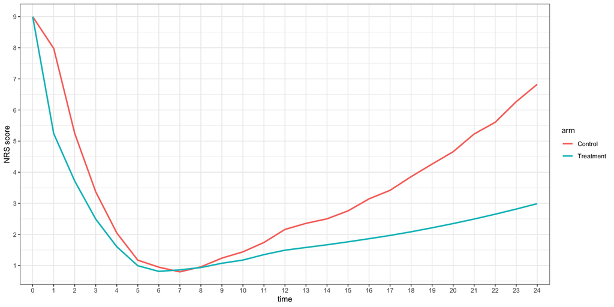

Figure 1: Natural response curves

```r
x <- dat_guide_funct(n_measure = 25, diff_ratio = 0.08, arm_name = c("Treatment", "Control"))
x$plot
```

**Function 2**

**To Simulate data (wide form)**

```r
sim_dat_wide_nocov <- function(N = 100, n_measure = 25, arm_name = c("Treatment", "Control"), diff_ratio = 0.08) {
  dat_guide <- dat_guide_funct(n_measure = n_measure, arm_name = arm_name, diff_ratio = diff_ratio)

  y_mA <- dat_guide$y_mA
  y_mB <- dat_guide$y_mB

  df_matA <- df_matB <- matrix(ncol = n_measure, nrow = N)

  for (i in 1:n_measure) {
    df_matA[, i] <- extraDistr::rtpois(n = N, lambda = y_mA[i], b = 10)
    df_matB[, i] <- extraDistr::rtpois(n = N, lambda = y_mB[i], b = 10)
  }

  df_mat <- rbind(df_matA, df_matB) |> as.data.frame()
  names(df_mat) <- paste0("t", 0:(n_measure - 1))
  df_mat$id <- 1:(2*N)
  df_mat$group <- rep(arm_name, each = N)

  return(df_mat)
}

df_wide_sim <- sim_dat_wide_nocov(N = 1000, n_measure = 25, diff_ratio = 0.08, arm_name = c("Treatment", "Control"))
rbind(head(df_wide_sim), tail(df_wide_sim)) |> knitr::kable()
```

|  | t0 | t1 | t2 | t3 | t4 | t5 | t6 | t7 | t8 | t9 | t10 | t11 | t12 | t13 | t14 | t15 | t16 | t17 | t18 | t19 | t20 | t21 | t22 | t23 | t24 | id | group |
| --- | --- | --- | --- | --- | --- | --- | --- | --- | --- | --- | --- | --- | --- | --- | --- | --- | --- | --- | --- | --- | --- | --- | --- | --- | --- | --- | --- |
| 1 | 6 | 5 | 7 | 4 | 4 | 1 | 2 | 0 | 0 | 0 | 2 | 1 | 3 | 1 | 4 | 2 | 2 | 2 | 1 | 3 | 2 | 2 | 3 | 2 | 5 | 1 | Treatment |
| 2 | 5 | 5 | 7 | 5 | 0 | 0 | 1 | 3 | 3 | 3 | 2 | 1 | 3 | 1 | 3 | 2 | 2 | 0 | 2 | 2 | 4 | 2 | 1 | 2 | 4 | 2 | Treatment |
| 3 | 10 | 1 | 1 | 1 | 1 | 1 | 1 | 1 | 1 | 1 | 1 | 3 | 2 | 1 | 3 | 1 | 3 | 0 | 4 | 5 | 1 | 2 | 4 | 0 | 2 | 3 | Treatment |
| 4 | 6 | 6 | 5 | 2 | 2 | 0 | 1 | 1 | 0 | 1 | 1 | 2 | 1 | 1 | 1 | 2 | 1 | 3 | 2 | 3 | 3 | 5 | 3 | 3 | 2 | 4 | Treatment |
| 5 | 9 | 4 | 5 | 1 | 0 | 1 | 1 | 1 | 1 | 2 | 1 | 1 | 0 | 1 | 3 | 3 | 0 | 0 | 5 | 1 | 3 | 2 | 3 | 3 | 0 | 5 | Treatment |
| 6 | 8 | 4 | 1 | 4 | 3 | 2 | 0 | 2 | 2 | 1 | 2 | 3 | 5 | 2 | 2 | 3 | 4 | 5 | 2 | 3 | 4 | 2 | 1 | 7 | 7 | 6 | Treatment |
| 1995 | 9 | 3 | 5 | 4 | 3 | 1 | 0 | 0 | 1 | 0 | 0 | 2 | 0 | 2 | 6 | 6 | 1 | 5 | 3 | 5 | 2 | 1 | 4 | 5 | 8 | 1995 | Control |
| 1996 | 10 | 8 | 3 | 2 | 1 | 2 | 2 | 1 | 2 | 3 | 0 | 2 | 5 | 1 | 1 | 1 | 2 | 4 | 8 | 6 | 5 | 6 | 4 | 4 | 9 | 1996 | Control |
| 1997 | 8 | 10 | 3 | 5 | 1 | 0 | 0 | 0 | 0 | 2 | 1 | 3 | 2 | 4 | 1 | 3 | 1 | 3 | 3 | 5 | 6 | 3 | 4 | 5 | 6 | 1997 | Control |
| 1998 | 8 | 5 | 6 | 3 | 1 | 1 | 0 | 0 | 0 | 0 | 1 | 2 | 5 | 1 | 4 | 2 | 10 | 6 | 3 | 3 | 8 | 4 | 5 | 7 | 6 | 1998 | Control |
| 1999 | 7 | 6 | 2 | 3 | 0 | 1 | 0 | 2 | 0 | 2 | 1 | 2 | 2 | 5 | 0 | 3 | 3 | 3 | 3 | 5 | 3 | 7 | 4 | 3 | 4 | 1999 | Control |
| 2000 | 6 | 5 | 8 | 5 | 2 | 1 | 1 | 0 | 0 | 3 | 1 | 1 | 1 | 8 | 3 | 3 | 6 | 3 | 3 | 6 | 5 | 3 | 5 | 3 | 9 | 2000 | Control |

**Function 3**

**Create response dataset (change from baseline i.e., ≥50% improvement)**

```r
sim_dat_change_long_nocov <- function(cutoff = -0.5, dat)
{
  # generate data
  df <- dat

  for (i in 1:nrow(df)) {
    for (j in 2:(ncol(df)-2)) {
      if (df[i, 1] > 0) {
        df[i, j] <- ifelse((df[i, j] - df[i, 1])/df[i, 1] <= cutoff, 1, 0)
      } else {
        df[i, j] <- ifelse((df[i, j] == df[i, 1]), 1, 0)
      }
    }
  }

  df[, 1] <- 0

  df_change_long <- df |>
    gather(-c(id, group), key = "t", value = "prob") |>
    mutate(t = parse_number(t)) |>
    ungroup() |> as.data.frame()

  return(df_change_long)
}

df_change <- sim_dat_change_long_nocov(cutoff = -0.5, dat = df_wide_sim)
rbind(head(df_change), tail(df_change)) |> knitr::kable()
```

|  | id | group | t | prob |
| --- | --- | --- | --- | --- |
| 1 | 1 | Treatment | 0 | 0 |
| 2 | 2 | Treatment | 0 | 0 |
| 3 | 3 | Treatment | 0 | 0 |
| 4 | 4 | Treatment | 0 | 0 |
| 5 | 5 | Treatment | 0 | 0 |
| 6 | 6 | Treatment | 0 | 0 |
| 49995 | 1995 | Control | 24 | 0 |
| 49996 | 1996 | Control | 24 | 0 |
| 49997 | 1997 | Control | 24 | 0 |
| 49998 | 1998 | Control | 24 | 0 |
| 49999 | 1999 | Control | 24 | 0 |
| 50000 | 2000 | Control | 24 | 0 |

**Visualize the Group response curve**

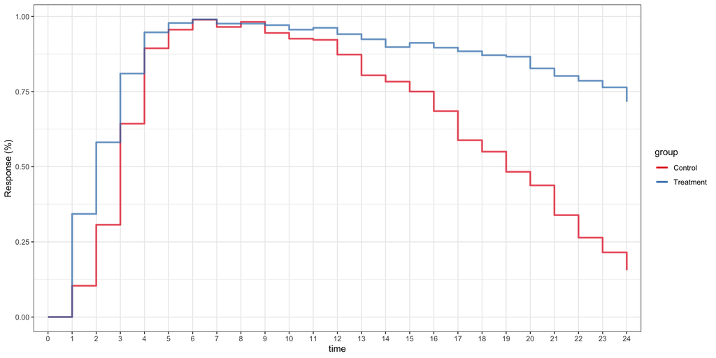

Figure 2: Natural response curves (on the binary scale)

```r
plot_GRO <- function(dat) {
  indat <- dat
  plot_step <- indat |>
    group_by(group, t) |>
    summarise(prob = mean(prob)) |> ungroup() |>
    ggplot(aes(x = as.factor(t), y = prob, color = group, group = group)) +
    geom_step(linewidth = 1, alpha = 0.7) +
    scale_color_brewer(palette = "Set1") +
    guides(col = guide_legend(override.aes = list(alpha = 1))) +
    labs(x = "time", y = "Response (%)") +
    theme_bw()

  plot_line <- indat |>
    group_by(group, t) |>
    summarise(prob = mean(prob)) |> ungroup() |>
    ggplot(aes(x = as.factor(t), y = prob, color = group, group = group)) +
    geom_line(linewidth = 1, alpha = 0.7) +
    scale_color_brewer(palette = "Set1") +
    guides(col = guide_legend(override.aes = list(alpha = 1))) +
    labs(x = "time", y = "Response (%)") +
    theme_bw()
  return(list(step = plot_step, line = plot_line))
}

y <- plot_GRO(dat = df_change)
y$step
```

**Function 3a**

**Group Responses Outcome Over Time (GROOT) based on GRO (i.e., average curve)**

```r
auc_funct <- function(a = 1, b, dat, idvar = "id", respvar = "prob", tvar = "t", grvar = "group") {

  auc_nonpar <- function(a = 1, b, dat, arm) {
    dat$group <- dat[, grvar]

    indat <- dat[dat$group == arm, ]

    indat$id <- indat[, idvar]
    indat$prob <- indat[, respvar]
    indat$t <- indat[, tvar]

    indat_sum <- indat |>
      group_by(t) |>
      summarise(prob = mean(prob, na.rm = T),
                n = n(),
                var = (prob*(1-prob))/(n-1)) |>
      as.data.frame()

    # Calculate AUC as step function
    intev       <- b - a
    idx         <- a <= indat_sum$t & indat_sum$t <= b
    time        <- c(indat_sum$t[idx], b)
    resp        <- indat_sum$prob[idx]
    var_id      <- indat_sum$var[idx]
    time_diff   <- diff(c(time))
    areas_diff  <- time_diff * resp/intev
    area        <- sum(areas_diff)
    # Check!!
    var_area    <- sum((time_diff^2)*var_id)/(intev^2)
    return(list(area = area, var = var_area))
  }


  multiarm <- function(val){
    auc_nonpar(arm   = val,
               a     = a,
               b     = b,
               dat   = dat)
  }


  arm_name <- as.character(unique(sort(dat$group)))
  area_mat <- t(sapply(arm_name, multiarm))

  # Set up result matrix
  res_mat <- cbind(area_mat, matrix(NA, length(arm_name), 6))
  res_mat[, 3] <- unlist(res_mat[, 1]) - sqrt(unlist(res_mat[, 2]))*qnorm(1 - 0.05/2)
  res_mat[, 4] <- unlist(res_mat[, 1]) + sqrt(unlist(res_mat[, 2]))*qnorm(1 - 0.05/2)

  if (length(arm_name) > 1) {
    for (j in 2:length(arm_name)) {
      # Difference
      res_mat[j, 5] <- area_mat[[1, 1]] - area_mat[[j, 1]]
      # SE difference
      res_mat[j, 6] <- sqrt(area_mat[[1, 2]] + area_mat[[j, 2]])
      # z-score
      res_mat[j, 7] <- res_mat[[j, 5]]/res_mat[[j, 6]]
      # p-value (1 - pchisq(res_mat[[2, 7]]^2, 1))
      res_mat[j, 8] <- pnorm(-abs(res_mat[[j, 7]])) * 2
    }
  }

  colnames(res_mat) <- c("area", "var", "lb", "ub", "diff", "se_diff", "z", "pval")

  return(res_mat)
}
```

**Function 3b**

**GROOT based on Participant-Level Outcome (i.e., Mean ROOT)**

```r
auc_funct_idv <- function(a = 1, b, dat, idvar = "id", respvar = "prob", tvar = "t", grvar = "group") {

  auc_nonpar <- function(a = 1, b, dat, arm) {
    dat$group <- dat[, grvar]

    indat <- dat[dat$group == arm, ]

    indat$id <- indat[, idvar]
    indat$prob <- indat[, respvar]
    indat$t <- indat[, tvar]

    # Define lag variable to indicate time-interval
    intev       <- b - a


    indat_sum <- indat |>
      arrange(id, t) |>
      group_by(id) |>
      mutate(tlag = lag(t, default = 0),
             time_diff = t - tlag,
             areas_diff = prob*time_diff) |>
      filter(a <= t & t < b) |>
      summarise(area_ind = sum(areas_diff)/intev,
                n = n(),
                var_ind = area_ind*(1-area_ind)/(n-1))


    area        <- mean(indat_sum$area_ind)
    # Check!!!!
    var_area    <- sum(indat_sum$var_ind)/nrow(indat_sum)^2

    return(list(area = area, var = var_area))
  }

  multiarm <- function(val){
    auc_nonpar(arm   = val,
               a     = a,
               b     = b,
               dat   = dat)
  }

  arm_name <- as.character(unique(sort(dat$group)))
  area_mat <- t(sapply(arm_name, multiarm))

  # Set up result matrix
  res_mat <- cbind(area_mat, matrix(NA, 2, 6))
  res_mat[, 3] <- unlist(res_mat[, 1]) - sqrt(unlist(res_mat[, 2]))*qnorm(1 - 0.05/2)
  res_mat[, 4] <- unlist(res_mat[, 1]) + sqrt(unlist(res_mat[, 2]))*qnorm(1 - 0.05/2)

  if (length(arm_name) > 1) {
    for (j in 2:length(arm_name)) {
      # Difference
      res_mat[j, 5] <- area_mat[[1, 1]] - area_mat[[j, 1]]
      # SE difference
      res_mat[j, 6] <- sqrt(area_mat[[1, 2]] + area_mat[[j, 2]])
      # z-score
      res_mat[j, 7] <- res_mat[[j, 5]]/res_mat[[j, 6]]
      # p-value (1 - pchisq(res_mat[[2, 7]]^2, 1))
      res_mat[j, 8] <- pnorm(-abs(res_mat[[j, 7]])) * 2
    }
  }

  colnames(res_mat) <- c("area", "var", "lb", "ub", "diff", "se_diff", "z", "pval")

  return(res_mat)
}
```

### Compare two functions (GROOT and mean ROOT)

```r
# Based on average response
auc_res <- auc_funct(a = 1, b = 25, dat = df_change)
auc_res |> knitr::kable()
```

|  | area | var | lb | ub | diff | se_diff | z | pval |
| --- | --- | --- | --- | --- | --- | --- | --- | --- |
| Control | 0.648375 | 6.03580142642643e-06 | 0.643559786336048 | 0.653190213663951 | NA | NA | NA | NA |
| Treatment | 0.857375 | 4.22882778611945e-06 | 0.853344507747163 | 0.861405492252838 | -0.209000000000001 | 0.00320384600325076 | -65.2340967037554 | 0 |

```r
# Based on individual response
auc_res2 <- auc_funct_idv(a = 1, b = 25, dat = df_change)
auc_res2 |> knitr::kable()
```

|  | area | var | lb | ub | diff | se_diff | z | pval |
| --- | --- | --- | --- | --- | --- | --- | --- | --- |
| Control | 0.648375 | 9.00717089371985e-06 | 0.642492766063885 | 0.654257233936115 | NA | NA | NA | NA |
| Treatment | 0.857375 | 4.67247886473431e-06 | 0.853138358033839 | 0.861611641966161 | -0.209 | 0.00369860105424391 | -56.507851734965 | 0 |

The two estimates for area under the curves are identical, however, standard errors are slightly different. I need to check this!

### Comparing power (Work in progress)

## Aim 2: Model-based GROOT

### Introduction

The non-parametric GROOT provides an accurate way to measure area under the group response curve. However, it has some disadvantages:

- Requires balanced longitudinal data (i.e., requires patients having the same number of repeated measurements obtained at a common set of occasions)
- Cannot adjust for covariates or selection bias.

To address that problem, we proposed model-based approach, using model with flexible terms (on time variable) to model the responses of patients and calculate the GROOT based on the predicted average response curve.

### Methods & Results

We propose a simple method for model-based GROOT with two main steps:

- Step 1: fit the response curve using Generalized Addictive Model, with smooth terms for time. Obtain the model predicted values for model-based group response curves.
- Step 2: Calculate area under the model-based group response curves by integration methods (e.g., trapezoidal method or adaptive quadrature)

**Set up data**

```r
df_wide_sim <- sim_dat_wide_nocov(N = 1000, n_measure = 25, diff_ratio = 0.08, arm_name = c("Treatment", "Control"))
df <- sim_dat_change_long_nocov(cutoff = -0.5, dat = df_wide_sim)
```

#### Step 1

**Fitting GAM and obtain the model predicted values for responses**

```r
gam_m <- gam(prob ~ group + s(t, k = 15) + s(id, t, bs = "re"),
             data = df, method = "REML", family = binomial)

summary(gam_m)
```

```
Family: binomial
Link function: logit

Formula:
prob ~ group + s(t, k = 15) + s(id, t, bs = "re")

Parametric coefficients:
               Estimate Std. Error z value Pr(>|z|)
(Intercept)     1.23472    0.04631   26.66   <2e-16 ***
groupTreatment  1.15301    0.04169   27.66   <2e-16 ***
---
Signif. codes:  0 '***' 0.001 '**' 0.01 '*' 0.05 '.' 0.1 ' ' 1

Approximate significance of smooth terms:
            edf Ref.df Chi.sq p-value
s(t)    13.4060  13.93   8573  <2e-16 ***
s(id,t)  0.9945   1.00    180  <2e-16 ***
---
Signif. codes:  0 '***' 0.001 '**' 0.01 '*' 0.05 '.' 0.1 ' ' 1

R-sq.(adj) =  0.402   Deviance explained = 35.5%
-REML =  19057  Scale est. = 1         n = 50000
```

```r
# gam.check(gam_m)
```

**Check actual vs prediction values**

The predicted values from GAM are similar to the observed response probability

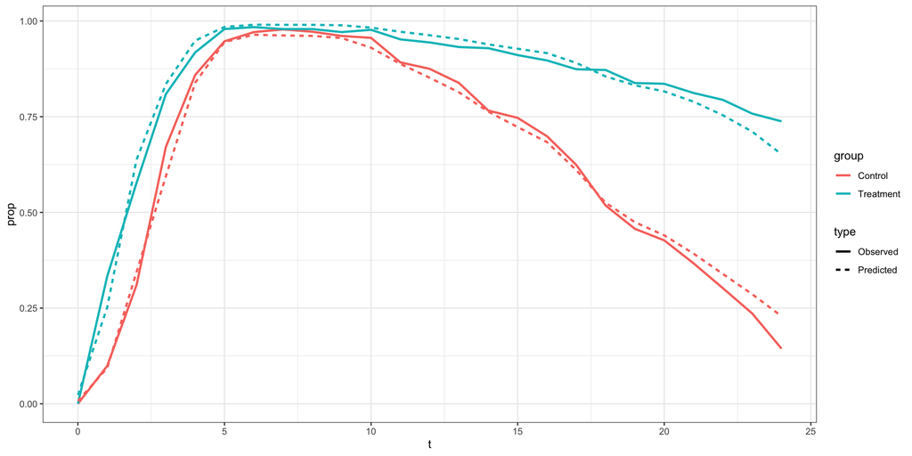

Figure 3: Predicted (from GAM) and observered response curves

```r
df$pred <- predict(gam_m, type = "response")

df |> group_by(group, t) |>
  summarise(Observed = mean(prob),
            Predicted = mean(pred)) |>
  gather(-c(group, t), key = "type", value = prop) |>
  ggplot(aes(x = t, y = prop, color = group)) +
  geom_line(aes(linetype = type), linewidth = 1) +
  theme_bw()
```

#### Step 2

**Calculate area under the model-based group response curves by trapezoidal rule**

```r
# Response and variance prediction
df$pred <- predict(gam_m, type = "response")
df$pred_var <- (predict(gam_m, type = "response", se.fit = TRUE)$se.fit)^2

# Define function
auc_smooth_trap <- function(a, b,  dat, resvar, errvar, tvar = "t") {
  indat <- dat

  indat$pred <- indat[, resvar]
  indat$varfit <- indat[, errvar]
  indat$t <- indat[, tvar]

  indat_sum <- indat |>
    group_by(t) |>
    summarise(prob = mean(pred),
              n = n(),
              var = (prob*(1-prob))/n + sum(varfit)/(n^2)) |>
    as.data.frame()

  intev        <- b - a
  idx          <- a <= indat_sum$t & indat_sum$t <= b
  time         <- indat_sum$t[idx]
  pred         <- indat_sum$prob[idx]
  var          <- indat_sum$var[idx]
  # AUC using trapezoidal rule (pracma::trapz(time[ord],pred[ord])/intev)
  ord          <- order(time)
  area         <- sum(diff(time[ord])*zoo::rollmean(pred[ord], 2))/intev
  var_area     <- sum((diff(time[ord])^2)*(zoo::rollsum(var[ord], 2)/4))/intev^2
  se_area      <- sqrt(var_area)
  return(list(area = area, se = se_area))
}
```

```r
auc_smooth_tr <- auc_smooth_trap(a = 0, b = 24, dat = df |> filter(group == "Treatment"), resvar = "pred", errvar = "pred_var")
auc_smooth_ct <- auc_smooth_trap(a = 0, b = 24, dat = df |> filter(group == "Control"), resvar = "pred", errvar = "pred_var")
```

Model-based GROOT for control group

```r
auc_smooth_ct$area
```

```
[1] 0.6457441
```

Model-based GROOT for treatment group

```r
auc_smooth_tr$area
```

```
[1] 0.8439825
```

The estimates are similar to non-parametric GROOT

```r
auc_np <- auc_funct(a = 1, b = 25, dat = df)
auc_np[, "area"]
```

```
$Control
[1] 0.6506667

$Treatment
[1] 0.8580417
```

## Aim 3: Model-based GROOT with g-methods

### Introduction

In this section, we illustrate the process of applying three well-known methods to estimate causal effects in the context of existing confounders: parametric g-formula, inverse probability weighting, and double-robust estimator. We did a simulation to compare the performance of these methods under different scenarios.

### Methods

The simulation followed the ADEMP framework (**A**ims, **D**ata-generating mechanism, **E**stimands, **M**ethods, **P**erformance measure) proposed by Morris et al., 2019. Such elements are presented below.

- Aim: To compare the performance of different estimation methods to obtain causal estimates under the presence of confounders with different scenarios.
- Data-generating mechanism: Four simulation mechanisms were set: small confounding, medium confounding, large confounding, and large confounding with model misspecification. Details are presented in section Section 1.3.2.1
- Estimands: Group Responses Outcome Over Time (GROOT) estimated by the area under the group response curve. The absolute difference between GROOTs of two treatment arms was also calculated.
- Methods: The the g-methods were used: Parametric g-formula (PG), Inverse Probability Weighting (IPW), and Double-robust estimator (DB). The estimates were compared to the unadjusted estimates and the true values.
- Performance measures: We compared the performance of these methods using bias, which was calculated as absolute bias: $|\text{True GROOT - estimate GROOT}|$.

#### Simulation setup

We first set up three confounding mechanisms (i.e., *“small”*, *“medium”*, and *“large”*) illustrating different situations of *“small”*, *“medium”*, and *“large”* confounding effects in terms of the magnitude of absolute bias for GROOT difference as well as the number of confounders (i.e., one, two, and three, respectively). Figure 4 shows the Directed Acyclic Graphs (DAG) of these three confounding mechanisms. To illustrate a problem that usually happens in real-world situations, which is unobserved confounders, we set U as an unobserved variable in the DAG.

- In the *“small”* confounding mechanism, there is a backdoor path from $Y_t \leftarrow U \rightarrow X_1 \rightarrow A$. Thus, conditioning on $X_1$ is sufficient to eliminate confounding (Figure 4 (a))
- In the *“medium”* confounding mechanism, two backdoor paths were created: (1) $Y_t \leftarrow U \rightarrow X_1 \rightarrow A$ and (2) $Y_t \leftarrow X_3 \rightarrow A$. Thus, to eliminate confounding, both $X_1$ and $X_3$ need to be controlled (Figure 4 (b)).
- In the *“large”* confounding mechanism, three backdoor paths were created: (1) $Y_t \leftarrow U \rightarrow X_1 \rightarrow A$, (2) $Y_t \leftarrow X_3 \rightarrow A$, and (3) $Y_t \leftarrow U \rightarrow X_2 \rightarrow A$. Therefore, a minimum set of $X_1$, $X_2$, and $X_3$ is needed to eliminate confounding (Figure 4 (c)).

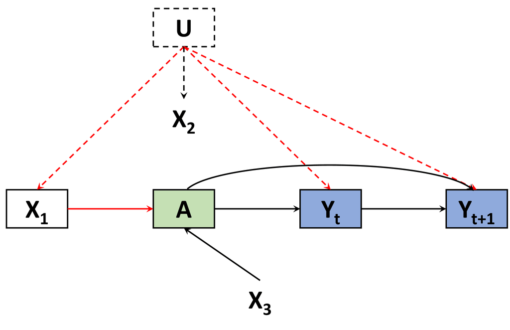

(a) “Small” confounding

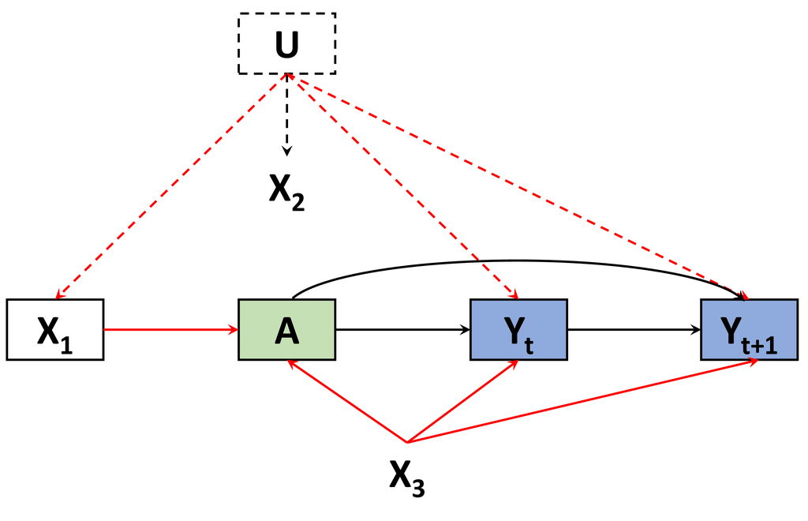

(b) “Medium” confounding

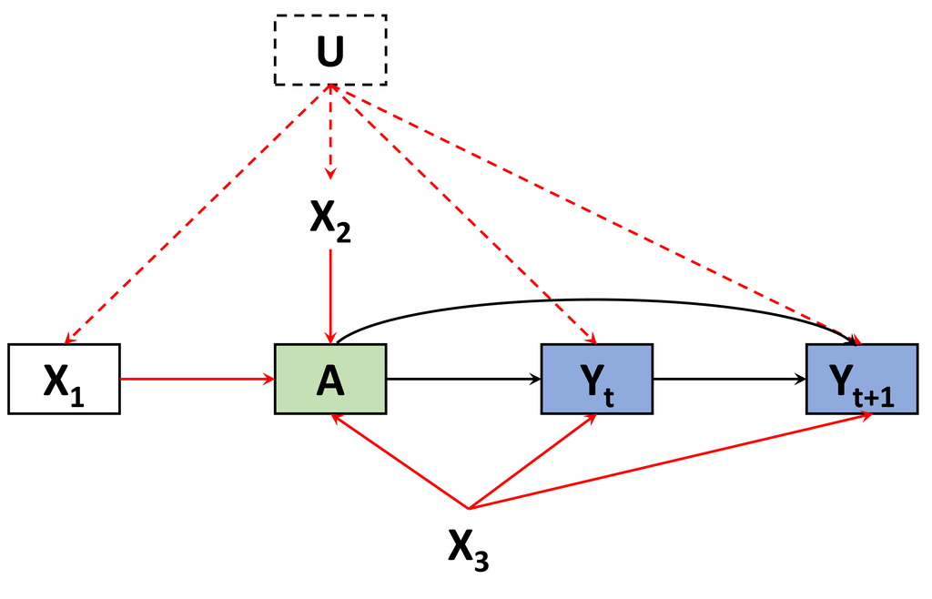

(c) “Large” confounding

Figure 4: Directed Acyclic Graphs illustrate three mechanisms of confounding effects for the simulation

Based on these three confounding scenarios, we set up the simulation with four scenarios that can be classified into two main situations:

- **Model correctly specified**: for the first three scenarios, we correctly controlled confounders based on each confounding scenario (i.e., scenario 1: $X_1$, scenario 2: $X_1$ and $X_3$, scenario 3: $X_1$, $X_2$, and $X_3$
- **Model misspecification**: In this scenario, we used the same confounding mechanism as scenario 3, except that we intentionally misspecified the models. In particular, in the model for treatment assignment (i.e., for IPW), we included only intercept instead of $X_1$, $X_2$, and $X_3$. Similarly, for the outcome regression model (i.e., g-formula), the model with only intercept was used. Thus, creating three situations for DB:
  - The model for treatment assignment was misspecified but the outcome regression model was correct (DB-A)
  - The model for treatment assignment was correct but the outcome regression model was misspecified (DB-Y).
  - Both treatmet and outcome models were misspecified (DB-AY)

#### Data generation

The data for each scenario was generated according to its confounding mechanism. The magnitude of the relationship between variables was reflected by the coefficients. For each scenario, we created datasets with 1000 samples. A loop of 1000 iterations was then performed, and the everage bias over 1000 iterations were obtained. The R code is provided in the [this GitHub repository](https://github.com/khuongquynhlong/grootCI). The details of each scenario are given in the following sections.

##### Scenario 1: “Small” confounding

$$\begin{align*} \label{eq:Scenario1}
&U \sim N(0, 2) \nonumber\\
&X_1 \sim \text{Bin}(n, p_{x1}) ;~~~~~~~~~~ \text{with: logit}(p_{x1}) = 0.5^{*} \text{U}\nonumber\\
&X_2 = 0.5 ^{*} \text{U} + \varepsilon_{x2}; ;~~~~~~~ \text{with: } \varepsilon_{x2} \sim N(0, 0.1)& \nonumber\\
&X_3 \sim N(0, 2) \nonumber\\
&A \sim \text{Bin}(n, p_a) ;~~~~~~~~~~~~~~ \text{with: logit}(p_a) = 0.5^{*}X_1 + 0.5^{*} X_3 \nonumber\\
&Y_t^{(1)} \sim \text{Bin}(n, p_{y^{(1)}}) ;~~~~~~~~ \text{with: logit}(p_{y^{(1)}}) = \text{logit}({\color{Red}f_0(t)}) + I_{(\text{A}=1)} + {\color{Red}0.5^{*} \text{U}} \nonumber\\
&Y_t^{(0)} \sim \text{Bin}(n, p_{y^{(0)}}) ;~~~~~~~~ \text{with: logit}(p_{y^{(0)}}) = \text{logit}({\color{Red}f_0(t)}) + I_{(\text{A}=1)} + {\color{Red}0.5^{*} \text{U}} \nonumber\\
&Y_t = Y_t^{(1)*}A + Y_t^{(0)*}(1 - A) \nonumber\\
\end{align*}$$

Where $f_0(t)$ indicates the baseline response probability at time $t$. We assumed the nature response to pain treatment is as follow:

- The response probability starts at zero, rises to a peak, and then gradually declines. $t$ is set from 0 to 24 hours, the response ranges from 0 to 1. Therefore Weibull distribution or log-normal distribution may be straightforward to describe the response probability.
- Here we used Weibull distribution. We assumed the response peak is at hours 3-5 with about maximum of 75% of participants response. The parameters for Weibull distribution are set as:
  - The scale parameter is set at 15 ($\lambda$ = 15)
  - Shape parameter is set at 1.3 ($k$ = 1.3)
  - A scale factor to make sure the prob reachs a peak of 0.75

Therefore $f_0(t) \sim Weibull(\lambda = 15, k = 1.3)$

##### Scenario 2: “Medium” confounding

$$\begin{align*}
&U \sim N(0, 2) \nonumber\\
&X_1 \sim \text{Bin}(n, p_{x1}) ;~~~~~~~~~~ \text{with: logit}(p_{x1}) = 0.5^{*} \text{U}\nonumber\\
&X_2 = 0.5 ^{*} \text{U} + \varepsilon_{x2}; ;~~~~~~~ \text{with: } \varepsilon_{x2} \sim N(0, 0.1)& \nonumber\\
&X_3 \sim N(0, 2) \nonumber\\
&A \sim \text{Bin}(n, p_a) ;~~~~~~~~~~~~~~ \text{with: logit}(p_a) = 0.5^{*}X_1 + 0.5^{*} X_3 \nonumber\\
&Y_t^{(1)} \sim \text{Bin}(n, p_{y^{(1)}}) ;~~~~~~~~ \text{with: logit}(p_{y^{(1)}}) = \text{logit}({\color{Red}f_0(t)}) + I_{(\text{A}=1)} + {\color{Red}0.5^{*} \text{U} + 0.5^{*} X_3} \nonumber\\
&Y_t^{(0)} \sim \text{Bin}(n, p_{y^{(0)}}) ;~~~~~~~~ \text{with: logit}(p_{y^{(0)}}) = \text{logit}({\color{Red}f_0(t)}) + I_{(\text{A}=1)} + {\color{Red}0.5^{*} \text{U} + 0.5^{*} X_3} \nonumber\\
&Y_t = Y_t^{(1)*}A + Y_t^{(0)*}(1 - A) \nonumber\\
\end{align*}$$

Where $f_0(t)$ indicates the baseline response probability at time $t$. $f_0(t) \sim Weibull(\lambda = 15, k = 1.3)$

##### Scenario 3: “Large” confounding

Where $f_0(t)$ indicates the baseline response probability at time $t$. $f_0(t) \sim Weibull(\lambda = 15, k = 1.3)$

##### Scenario 4: “Large” confounding with model misspecification

In this scenario, we used the same mechanism of scenario 3 except that we intentionally misspecified the models

#### Define all functions

**Function 1**

**Function for** $f_0(t)$

```r
gen_WB_curve <- function(t = 24, peak = 0.75, lambda = 15, k = 1.3) {
  x <- seq(0, t)
  # Weibull PDF
  weibull_pdf <- dweibull(x, shape = k, scale = lambda)

  # Scale the y-axis to have a peak around 0.75
  scaling_factor <- peak / max(weibull_pdf)
  weibull_pdf_scaled <- weibull_pdf * scaling_factor

  df_WB <- data.frame(t = x, response = weibull_pdf_scaled)
  return(df_WB)
}
```

**Function 2**

**Simulate data for 3 scenarios**

```r
genData <- function(n, scen, t = 24, peak = 0.75, lambda = 15, k = 1.3) {

  # Generate natural response curve
  df_WB <- gen_WB_curve(t = t, peak = peak, lambda = lambda, k = k)
  u    <- rnorm(n, 0, 2)
  x1   <- rbinom(n, size = 1, prob = plogis(0.5*u))
  x2   <- 0.5*u + rnorm(n, 0, 0.1)
  x3   <- rnorm(n, 0, 2)

  # Set up treatment A and outcome Y under different scenarios
  df_mat <- matrix(NA, n, (t+1)*3 + 4)

  df_mat[, (t+1)*3 + 2] <- x1
  df_mat[, (t+1)*3 + 3] <- x2
  df_mat[, (t+1)*3 + 4] <- x3

  if (scen == "small") {
    A    <- rbinom(n, size=1, prob = plogis(0.5*x1 + 0.5*x3))

    df_mat[, (t+1)*3 + 1] <- A

    for (i in 2:(t+1)) {
      # counterfactual outcome for A = 1
      yt1 <- rbinom(n, size=1, prob = plogis(qlogis(df_WB$response[i]) + 1 + 0.5*u))

      # counterfactual outcome for A = 0
      yt0 <- rbinom(n, size=1, prob = plogis(qlogis(df_WB$response[i]) + 0 + 0.5*u))

      # Observed outcome
      yt <- yt1*A + yt0*(1 - A)

      df_mat[, 3*(i-2) + 4] <- yt1
      df_mat[, 3*(i-2) + 5] <- yt0
      df_mat[, 3*(i-2) + 6] <- yt

    }
    df_mat[, 1] <- rep(0, n)
    df_mat[, 2] <- rep(0, n)
    df_mat[, 3] <- rep(0, n)
  } else if (scen == "medium") {
    A    <- rbinom(n, size=1, prob = plogis(0.5*x1 + 0.5*x3))

    df_mat[, (t+1)*3 + 1] <- A

    for (i in 2:(t+1)) {
      # counterfactual outcome for A = 1
      yt1 <- rbinom(n, size=1, prob = plogis(qlogis(df_WB$response[i]) + 1 + 0.5*u + 0.5*x3))

      # counterfactual outcome for A = 0
      yt0 <- rbinom(n, size=1, prob = plogis(qlogis(df_WB$response[i]) + 0 + 0.5*u + 0.5*x3))

      # Observed outcome
      yt <- yt1*A + yt0*(1 - A)

      df_mat[, 3*(i-2) + 4] <- yt1
      df_mat[, 3*(i-2) + 5] <- yt0
      df_mat[, 3*(i-2) + 6] <- yt

    }
    df_mat[, 1] <- rep(0, n)
    df_mat[, 2] <- rep(0, n)
    df_mat[, 3] <- rep(0, n)

  } else {
    A    <- rbinom(n, size=1, prob = plogis(0.5*x1 + 0.5*x3 + 0.5*x2))

    df_mat[, (t+1)*3 + 1] <- A

    for (i in 2:(t+1)) {
      # counterfactual outcome for A = 1
      yt1 <- rbinom(n, size=1, prob = plogis(qlogis(df_WB$response[i]) + 1 + 0.5*u + 0.75*x3 + 0.75*x2))

      # counterfactual outcome for A = 0
      yt0 <- rbinom(n, size=1, prob = plogis(qlogis(df_WB$response[i]) + 0 + 0.5*u + 0.75*x3 + 0.75*x2))

      # Observed outcome
      yt <- yt1*A + yt0*(1 - A)

      df_mat[, 3*(i-2) + 4] <- yt1
      df_mat[, 3*(i-2) + 5] <- yt0
      df_mat[, 3*(i-2) + 6] <- yt

    }
    df_mat[, 1] <- rep(0, n)
    df_mat[, 2] <- rep(0, n)
    df_mat[, 3] <- rep(0, n)
  }

  # Return data.frame
  colnames(df_mat) <- c("Y1_0", "Y0_0", "Y_0",
                        paste0(c("Y1_", "Y0_", "Y_"), rep(1:t, each = 3)),
                        "A", "x1", "x2", "x3")
  df_mat <- as.data.frame(df_mat)
  df_mat$id <- 1:n

  # Data for counterfactual outcome of A = 1
  df_Y1 <- df_mat |> select(id, starts_with("Y1_")) |>
    gather(-c(id), key = "t", value = "Y1") |>
    mutate(t = as.numeric(str_remove_all(t, "Y1_"))) |>
    arrange(id, t)

  # Data for counterfactual outcome of A = 0
  df_Y0 <- df_mat |> select(id, starts_with("Y0_")) |>
    gather(-c(id), key = "t", value = "Y0") |>
    mutate(t = as.numeric(str_remove_all(t, "Y0_"))) |>
    arrange(id, t)

  # Data for observed outcome of
  df_Y <- df_mat |> select(id, A, x1, x2, x3, starts_with("Y_")) |>
    gather(-c(id, A, x1, x2, x3), key = "t", value = "Y") |>
    mutate(t = as.numeric(str_remove_all(t, "Y_"))) |>
    arrange(id, t)

  df_all <- df_Y |>
    left_join(df_Y1, by = c("id", "t")) |>
    left_join(df_Y0, by = c("id", "t"))

 return(df_all)
}
```

**Function 3**

**Plot simulated data**

```r
plot_genData <- function(n = 1000, scen, t = 24, peak = 0.7, lambda = 15, k = 1.3) {
  indat <- genData(n = 1000, scen = scen, t = 24, peak = 0.7, lambda = 15, k = 1.3)

  f1_ob <- indat |>
    group_by(t, A) |>
    summarise(prob = mean(Y)) |>
    ggplot(aes(x = as.factor(t), y = prob, color = as.factor(A), group = as.factor(A))) +
    geom_line(linewidth = 1) +
    scale_y_continuous(limits = c(0, 1)) +
    scale_color_brewer(palette = "Set1") +
    labs(x = "Time", y = "Response (%)", color = "Group",
         title = "Observed reponse curves (biased)") +
    theme_bw()

  A1_sum <- indat |>
    group_by(t) |>
    summarise(prob = mean(Y1), group = "1")

  A0_sum <- indat |>
    group_by(t) |>
    summarise(prob = mean(Y0), group = "0")

  f1_cft <- rbind(A1_sum, A0_sum) |>
    ggplot(aes(x = as.factor(t), y = prob, color = group, group = group)) +
    geom_line(linewidth = 1) +
    scale_y_continuous(limits = c(0, 1)) +
    scale_color_brewer(palette = "Set1") +
    labs(x = "Time", y = "Response (%)", color = "Group",
         title = "Counterfactual reponse curves (true)") +
    theme_bw()
  return(cowplot::plot_grid(f1_cft, f1_ob, labels = "AUTO", ncol = 2))
}
```

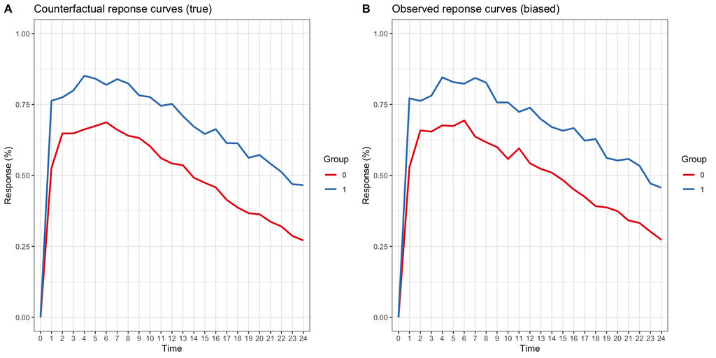

Figure 5: Small confounding: True and biased estimates

```r
set.seed(12345)
plot_genData(n = 1000, scen = "small")
```

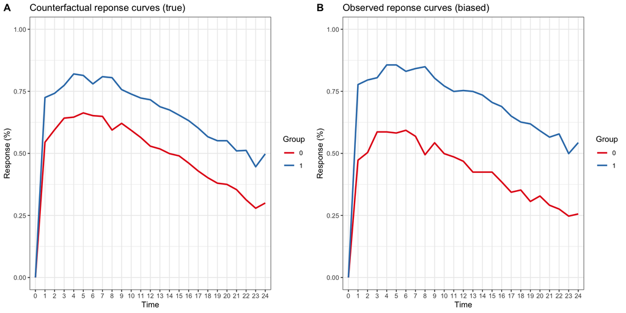

Figure 6: Medium confounding: True and biased estimates

```r
set.seed(12345)
plot_genData(n = 1000, scen = "medium")
```

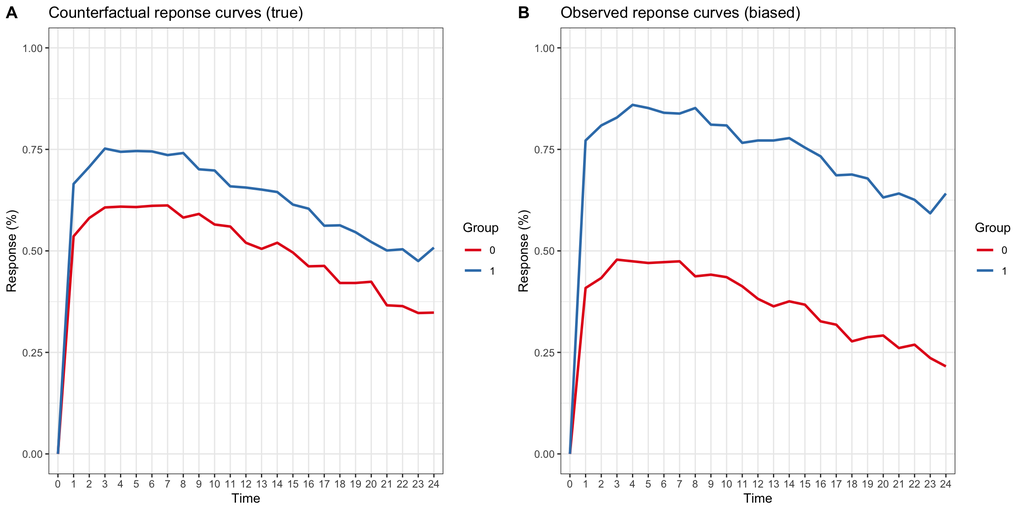

Figure 7: Large confounding: True and biased estimates

```r
set.seed(12345)
plot_genData(n = 1000, scen = "large")
```

**Function 4**

**Simplify the function to calculate area under the curve only (no SE)**

```r
auc_smooth_trap_area <- function(a, b, dat, resvar, tvar = "t") {
  indat <- dat

  indat$pred <- indat[, resvar]
  indat$t <- indat[, tvar]

  indat_sum <- indat |>
    group_by(t) |>
    summarise(prob = mean(pred)) |>
    as.data.frame()

  intev        <- b - a
  idx          <- a <= indat_sum$t & indat_sum$t <= b
  time         <- indat_sum$t[idx]
  pred         <- indat_sum$prob[idx]
  # AUC using trapezoidal rule (pracma::trapz(time[ord],pred[ord])/intev)
  ord          <- order(time)
  area         <- sum(diff(time[ord])*zoo::rollmean(pred[ord], 2))/intev
  return(area)
}
```

**Function 5**

**Do simulation to compare performance of different methods**

```r
doSimulation <- function(n = 1000, scen, t = 24, peak = 0.7, lambda = 15, k = 1.3,
                         a = 0, b = 24, boot = NULL, conf_lv = 0.95, seed = NULL) {
  if(!is.null(seed)) {
    set.seed(seed)
  }

  if (scen == "small") {
    dat         <- genData(n = n, scen = "small", t = t, peak = peak, lambda = lambda, k = k)
    formula1    <- Y ~  x1 + s(t)
    formula2    <- A ~  x1 + x3
    formula3    <- Y ~  x1 + bs(t, df = 5) # For svyglm() as mgcv cannot use ipw
  } else if (scen == "medium") {
    dat         <- genData(n = n, scen = "medium", t = t, peak = peak, lambda = lambda, k = k)
    formula1    <- Y ~  x1 + x3 + s(t)
    formula2    <- A ~  x1 + x3
    formula3    <- Y ~  x1 + x3 + bs(t, df = 5) # For svyglm() as mgcv cannot use ipw
  } else {
    dat         <- genData(n = n, scen = "large", t = t, peak = peak, lambda = lambda, k = k)
    formula1    <- Y ~  x1 + x2 + x3 + s(t)
    formula2    <- A ~  x1 + x2 + x3
    formula3    <- Y ~  x1 + x2 + x3 + bs(t, df = 5) # For svyglm() as mgcv cannot use ipw
  }

  trueAUC_Y1    <- auc_smooth_trap_area(a = a, b = b, dat = dat, resvar = "Y1")
  trueAUC_Y0    <- auc_smooth_trap_area(a = a, b = b, dat = dat, resvar = "Y0")
  trueAUC_diff  <- trueAUC_Y1 - trueAUC_Y0

  biasAUC_Y1    <- auc_smooth_trap_area(a = a, b = b, dat = dat[dat$A==1,], resvar = "Y")
  biasAUC_Y0    <- auc_smooth_trap_area(a = a, b = b, dat = dat[dat$A==0,], resvar = "Y")
  biasAUC_diff  <- biasAUC_Y1 - biasAUC_Y0


  #----- Parametric G-formula
  par_gform <- function(dat, ...) {
    indat       <- dat
    gam1        <- gam(formula1, data = indat[indat$A==1,], method = "REML", family = binomial)
    gam0        <- gam(formula1, data = indat[indat$A==0,], method = "REML", family = binomial)
    indat$pred1 <- predict(gam1, type = "response", newdata = indat |> mutate(A = 1))
    indat$pred0 <- predict(gam0, type = "response", newdata = indat |> mutate(A = 0))
    adj_AUC1    <- auc_smooth_trap_area(a = a, b = b, dat = indat, resvar = "pred1")
    adj_AUC0    <- auc_smooth_trap_area(a = a, b = b, dat = indat, resvar = "pred0")
    AUC_diff    <- adj_AUC1 - adj_AUC0
    return(list(adj_AUC1 = adj_AUC1, adj_AUC0 = adj_AUC0, AUC_diff = AUC_diff))
  }
  par_gform_auc <- par_gform(dat = dat)


  #----- IPW
  iptw <- function(dat, ...) {
    indat       <- dat
    ps_mod      <- glm(formula2, data=indat, family="binomial")
    pscore      <- ifelse(indat$A==0, 1-predict(ps_mod, type = "response"), predict(ps_mod, type = "response"))
    indat$w     <- 1/pscore
    glm_w       <- svyglm(Y ~ A + bs(t, df = 5), family = "quasibinomial",
        design = svydesign(~ 1, weights = ~ indat$w, data = indat))
    indat$pred  <- predict(glm_w, newdata = indat, type = "response")
    adj_AUC1    <- auc_smooth_trap_area(a = a, b = b, dat = indat[indat$A==1,], resvar = "pred")
    adj_AUC0    <- auc_smooth_trap_area(a = a, b = b, dat = indat[indat$A==0,], resvar = "pred")
    AUC_diff    <- adj_AUC1 - adj_AUC0
    return(list(adj_AUC1 = adj_AUC1, adj_AUC0 = adj_AUC0, AUC_diff = AUC_diff))
  }

  iptw_auc <- iptw(dat = dat)

  #----- Double-robust methods
  DB_both <- function(dat,...) {
    indat       <- dat
    ps_mod      <- glm(formula2, data=indat, family="binomial")
    pscore      <- ifelse(indat$A==0, 1-predict(ps_mod, type = "response"), predict(ps_mod, type = "response"))
    indat$w     <- 1/pscore
    glm1        <- svyglm(formula3, family = "quasibinomial",
                          design = svydesign(~ 1, weights = ~ indat$w[indat$A==1], data = indat[indat$A==1,]))
    glm0        <- svyglm(formula3, family = "quasibinomial",
                          design = svydesign(~ 1, weights = ~ indat$w[indat$A==0], data = indat[indat$A==0,]))
    indat$pred1 <- predict(glm1, type = "response", newdata = indat |> mutate(A = 1))
    indat$pred0 <- predict(glm0, type = "response", newdata = indat |> mutate(A = 0))
    adj_AUC1    <- auc_smooth_trap_area(a = a, b = b, dat = indat, resvar = "pred1")
    adj_AUC0    <- auc_smooth_trap_area(a = a, b = b, dat = indat, resvar = "pred0")
    AUC_diff    <- adj_AUC1 - adj_AUC0
    return(list(adj_AUC1 = adj_AUC1, adj_AUC0 = adj_AUC0, AUC_diff = AUC_diff))
  }

  DB_auc <- DB_both(dat = dat)


  #----- Double-robust methods: Misclassification of treatment model
  DB_A <- function(dat,...) {
    indat       <- dat
    ps_mod      <- glm(A ~ 1, data=indat, family="binomial")
    pscore      <- ifelse(indat$A==0, 1-predict(ps_mod, type = "response"), predict(ps_mod, type = "response"))
    indat$w     <- 1/pscore
    glm1        <- svyglm(formula3, family = "quasibinomial",
                          design = svydesign(~ 1, weights = ~ indat$w[indat$A==1], data = indat[indat$A==1,]))
    glm0        <- svyglm(formula3, family = "quasibinomial",
                          design = svydesign(~ 1, weights = ~ indat$w[indat$A==0], data = indat[indat$A==0,]))
    indat$pred1 <- predict(glm1, type = "response", newdata = indat |> mutate(A = 1))
    indat$pred0 <- predict(glm0, type = "response", newdata = indat |> mutate(A = 0))
    adj_AUC1    <- auc_smooth_trap_area(a = a, b = b, dat = indat, resvar = "pred1")
    adj_AUC0    <- auc_smooth_trap_area(a = a, b = b, dat = indat, resvar = "pred0")
    AUC_diff    <- adj_AUC1 - adj_AUC0
    return(list(adj_AUC1 = adj_AUC1, adj_AUC0 = adj_AUC0, AUC_diff = AUC_diff))
  }

  DB_A_auc <- DB_A(dat = dat)

  #----- Double-robust methods: Misclassification of outcome model
  DB_Y <- function(dat,...) {
    indat       <- dat
    ps_mod      <- glm(formula2, data=indat, family="binomial")
    pscore      <- ifelse(indat$A==0, 1-predict(ps_mod, type = "response"), predict(ps_mod, type = "response"))
    indat$w     <- 1/pscore
    glm1        <- svyglm(Y ~ bs(t, df = 5), family = "quasibinomial",
                          design = svydesign(~ 1, weights = ~ indat$w[indat$A==1], data = indat[indat$A==1,]))
    glm0        <- svyglm(Y ~ bs(t, df = 5), family = "quasibinomial",
                          design = svydesign(~ 1, weights = ~ indat$w[indat$A==0], data = indat[indat$A==0,]))
    indat$pred1 <- predict(glm1, type = "response", newdata = indat |> mutate(A = 1))
    indat$pred0 <- predict(glm0, type = "response", newdata = indat |> mutate(A = 0))
    adj_AUC1    <- auc_smooth_trap_area(a = a, b = b, dat = indat, resvar = "pred1")
    adj_AUC0    <- auc_smooth_trap_area(a = a, b = b, dat = indat, resvar = "pred0")
    AUC_diff    <- adj_AUC1 - adj_AUC0
    return(list(adj_AUC1 = adj_AUC1, adj_AUC0 = adj_AUC0, AUC_diff = AUC_diff))
  }
```

```r
  DB_Y_auc <- DB_Y(dat = dat)

  #----- Double-robust methods: Misclassification of both treatment and outcome models
  DB_AY <- function(dat,...) {
    indat       <- dat
    ps_mod      <- glm(A ~ 1, data=indat, family="binomial")
    pscore      <- ifelse(indat$A==0, 1-predict(ps_mod, type = "response"), predict(ps_mod, type = "response"))
    indat$w     <- 1/pscore
    glm1        <- svyglm(Y ~ bs(t, df = 5), family = "quasibinomial",
                          design = svydesign(~ 1, weights = ~ indat$w[indat$A==1], data = indat[indat$A==1,]))
    glm0        <- svyglm(Y ~ bs(t, df = 5), family = "quasibinomial",
                          design = svydesign(~ 1, weights = ~ indat$w[indat$A==0], data = indat[indat$A==0,]))
    indat$pred1 <- predict(glm1, type = "response", newdata = indat |> mutate(A = 1))
    indat$pred0 <- predict(glm0, type = "response", newdata = indat |> mutate(A = 0))
    adj_AUC1    <- auc_smooth_trap_area(a = a, b = b, dat = indat, resvar = "pred1")
    adj_AUC0    <- auc_smooth_trap_area(a = a, b = b, dat = indat, resvar = "pred0")
    AUC_diff    <- adj_AUC1 - adj_AUC0
    return(list(adj_AUC1 = adj_AUC1, adj_AUC0 = adj_AUC0, AUC_diff = AUC_diff))
  }

  DB_AY_auc <- DB_AY(dat = dat)


  df_est <- data.frame(
    method = c("Gform", "IPW", "DB", "DB_A", "DB_Y", "DB_AY"),
    trueAUC_Y1 = trueAUC_Y1,
    trueAUC_Y0 = trueAUC_Y0,
    biasAUC_Y1 = biasAUC_Y1,
    biasAUC_Y0 = biasAUC_Y0,
    adj_AUC1 = c(par_gform_auc$adj_AUC1, iptw_auc$adj_AUC1, DB_auc$adj_AUC1, DB_A_auc$adj_AUC1, DB_Y_auc$adj_AUC1, DB_AY_auc$adj_AUC1),
    adj_AUC0 = c(par_gform_auc$adj_AUC0, iptw_auc$adj_AUC0, DB_auc$adj_AUC0, DB_A_auc$adj_AUC0, DB_Y_auc$adj_AUC0, DB_AY_auc$adj_AUC0),
    true_AUC_diff = trueAUC_diff,
    bias_AUC_diff = biasAUC_diff,
    adj_AUC_diff = c(par_gform_auc$AUC_diff, iptw_auc$AUC_diff, DB_auc$AUC_diff, DB_A_auc$AUC_diff, DB_Y_auc$AUC_diff, DB_AY_auc$AUC_diff))

  if (!is.null(boot)) {

      #----- Bootstrap
      #=========================================================================
      df_result_b <- NULL


      #--- Bootstrap data
      for (i in 1:boot) {
        idx      <- sample(1:n, n, replace = T)
        freq_id  <- table(idx)
        df_boot  <- NULL

        for(j in 1:max(freq_id)) {
          # Loop over repeated id
          temp_df <- dat[dat$id %in% names(freq_id[freq_id %in% c(j:max(freq_id))]), ]
          temp_df$boot_id <- paste0(temp_df$id, "_", j)
          df_boot <- rbind(df_boot, temp_df)
        }

        trueAUC_Y1_b    <- auc_smooth_trap_area(a = a, b = b, dat = df_boot, resvar = "Y1")
        trueAUC_Y0_b    <- auc_smooth_trap_area(a = a, b = b, dat = df_boot, resvar = "Y0")
        trueAUC_diff_b  <- trueAUC_Y1_b - trueAUC_Y0_b

        biasAUC_Y1_b    <- auc_smooth_trap_area(a = a, b = b, dat = df_boot[df_boot$A==1,], resvar = "Y")
        biasAUC_Y0_b    <- auc_smooth_trap_area(a = a, b = b, dat = df_boot[df_boot$A==0,], resvar = "Y")
        biasAUC_diff_b  <- biasAUC_Y1_b - biasAUC_Y0_b


        #--- Bootstrap estimates

        # parametric G-formula
        par_gform_b <- par_gform(dat = df_boot)

        # IPW
        iptw_b <- iptw(dat = df_boot)

        # DB both
        DB_b <- DB_both(dat = df_boot)

        # Double-robust methods: Misclassification of treatment model
        DB_A_b <- DB_A(dat = df_boot)

        # Double-robust methods: Misclassification of outcome model
        DB_Y_b <- DB_Y(dat = df_boot)

        # Double-robust methods: Misclassification of both treatment and outcome models
        DB_AY_b <- DB_AY(dat = df_boot)

        df_b <- data.frame(
          method = c("Gform", "IPW", "DB", "DB_A", "DB_Y", "DB_AY"),
          trueAUC_Y1 = trueAUC_Y1_b,
          trueAUC_Y0 = trueAUC_Y0_b,
          biasAUC_Y1 = biasAUC_Y1_b,
          biasAUC_Y0 = biasAUC_Y0_b,
          adj_AUC1 = c(par_gform_b$adj_AUC1, iptw_b$adj_AUC1, DB_b$adj_AUC1, DB_A_b$adj_AUC1, DB_Y_b$adj_AUC1, DB_AY_b$adj_AUC1),
          adj_AUC0 = c(par_gform_b$adj_AUC0, iptw_b$adj_AUC0, DB_b$adj_AUC0, DB_A_b$adj_AUC0, DB_Y_b$adj_AUC0, DB_AY_b$adj_AUC0),
          true_AUC_diff = trueAUC_diff_b,
          bias_AUC_diff = biasAUC_diff_b,
          adj_AUC_diff = c(par_gform_b$AUC_diff, iptw_b$AUC_diff, DB_b$AUC_diff, DB_A_b$AUC_diff, DB_Y_b$AUC_diff, DB_AY_b$AUC_diff),
          iteration = i)

        df_result_b <- rbind(df_result_b, df_b)
      }

      # Summary data for bootstrap
      df_est <- df_result_b |>
        group_by(method) |>
        summarise(trueAUC_Y1_lb     = quantile(trueAUC_Y1, probs = (1 - conf_lv)/2),
                  trueAUC_Y1_ub     = quantile(trueAUC_Y1, probs = (1 + conf_lv)/2),
                  trueAUC_Y0_lb     = quantile(trueAUC_Y0, probs = (1 - conf_lv)/2),
                  trueAUC_Y0_ub     = quantile(trueAUC_Y0, probs = (1 + conf_lv)/2),
                  biasAUC_Y1_lb     = quantile(biasAUC_Y1, probs = (1 - conf_lv)/2),
                  biasAUC_Y1_ub     = quantile(biasAUC_Y1, probs = (1 + conf_lv)/2),
                  biasAUC_Y0_lb     = quantile(biasAUC_Y0, probs = (1 - conf_lv)/2),
                  biasAUC_Y0_ub     = quantile(biasAUC_Y0, probs = (1 + conf_lv)/2),
                  adj_AUC1_lb       = quantile(adj_AUC1, probs = (1 - conf_lv)/2),
                  adj_AUC1_ub       = quantile(adj_AUC1, probs = (1 + conf_lv)/2),
                  adj_AUC0_lb       = quantile(adj_AUC0, probs = (1 - conf_lv)/2),
                  adj_AUC0_ub       = quantile(adj_AUC0, probs = (1 + conf_lv)/2),
                  true_AUC_diff_lb  = quantile(true_AUC_diff, probs = (1 - conf_lv)/2),
                  true_AUC_diff_ub  = quantile(true_AUC_diff, probs = (1 + conf_lv)/2),
                  bias_AUC_diff_lb  = quantile(bias_AUC_diff, probs = (1 - conf_lv)/2),
                  bias_AUC_diff_ub  = quantile(bias_AUC_diff, probs = (1 + conf_lv)/2),
                  adj_AUC_diff_lb   = quantile(adj_AUC_diff, probs = (1 - conf_lv)/2),
                  adj_AUC_diff_ub   = quantile(adj_AUC_diff, probs = (1 + conf_lv)/2))|>
        ungroup() |>
        right_join(df_est, by = "method") |>
        datawizard::data_rotate(colnames = TRUE, rownames = "param")
  }
```

```r
  return(df_est)

}
```

### Results

**Run the 1000 iteration to calculate average bias**

The table below display the comparison between perfomance between different methods to control for confounders, as well as comparing to undajusted estimates.

```r
ave_bias_tab <- NULL

for (k in c("small", "medium", "large")) {
  for (i in 1:1000) {
    df_out          <- doSimulation(n = 1000, scen = k, seed = i)
    df_out$scenario <- k
    df_out$iter     <- i
    ave_bias_tab    <- rbind(ave_bias_tab, df_out)
  }
}

ave_bias_tab_sum <- ave_bias_tab |>
  group_by(scenario, method) %>%
  summarise(trueAUC_Y1 = mean(trueAUC_Y1),
            trueAUC_Y0 = mean(trueAUC_Y0),
            biasAUC_Y1 = mean(biasAUC_Y1),
            biasAUC_Y0  = mean(biasAUC_Y0),
            adj_AUC1  = mean(adj_AUC1),
            adj_AUC0 = mean(adj_AUC0),
            true_AUC_diff = mean(true_AUC_diff),
            bias_AUC_diff = mean(bias_AUC_diff),
            adj_AUC_diff = mean(adj_AUC_diff),
            bias_true_unadj = mean(abs(true_AUC_diff - bias_AUC_diff)),
            bias_true_adj = mean(abs(true_AUC_diff - adj_AUC_diff)))

ave_bias_tab_sum |> knitr::kable()
```

| scenario | method | trueAUC_Y1 | trueAUC_Y0 | biasAUC_Y1 | biasAUC_Y0 | adj_AUC1 | adj_AUC0 | true_AUC_diff | bias_AUC_diff | adj_AUC_diff | bias_true_unadj | bias_true_adj |
| --- | --- | --- | --- | --- | --- | --- | --- | --- | --- | --- | --- | --- |
| large | DB | 0.6208876 | 0.4914474 | 0.7385256 | 0.3410130 | 0.6172233 | 0.4883260 | 0.1294402 | 0.3975125 | 0.1288973 | 0.2680723 | 0.0005429 |
| large | DB_A | 0.6208876 | 0.4914474 | 0.7385256 | 0.3410130 | 0.6213899 | 0.4891928 | 0.1294402 | 0.3975125 | 0.1321971 | 0.2680723 | 0.0027569 |
| large | DB_AY | 0.6208876 | 0.4914474 | 0.7385256 | 0.3410130 | 0.7346851 | 0.3387531 | 0.1294402 | 0.3975125 | 0.3959321 | 0.2680723 | 0.2664919 |
| large | DB_Y | 0.6208876 | 0.4914474 | 0.7385256 | 0.3410130 | 0.6173636 | 0.4881286 | 0.1294402 | 0.3975125 | 0.1292350 | 0.2680723 | 0.0002052 |
| large | Gform | 0.6208876 | 0.4914474 | 0.7385256 | 0.3410130 | 0.6215423 | 0.4897222 | 0.1294402 | 0.3975125 | 0.1318200 | 0.2680723 | 0.0023798 |
| large | IPW | 0.6208876 | 0.4914474 | 0.7385256 | 0.3410130 | 0.6168643 | 0.4885662 | 0.1294402 | 0.3975125 | 0.1282981 | 0.2680723 | 0.0011421 |
| medium | DB | 0.6560052 | 0.4921862 | 0.7195675 | 0.4059782 | 0.6528138 | 0.4887745 | 0.1638190 | 0.3135893 | 0.1640394 | 0.1497703 | 0.0002204 |
| medium | DB_A | 0.6560052 | 0.4921862 | 0.7195675 | 0.4059782 | 0.6542907 | 0.4890049 | 0.1638190 | 0.3135893 | 0.1652858 | 0.1497703 | 0.0014668 |
| medium | DB_AY | 0.6560052 | 0.4921862 | 0.7195675 | 0.4059782 | 0.7158434 | 0.4033888 | 0.1638190 | 0.3135893 | 0.3124547 | 0.1497703 | 0.1486357 |
| medium | DB_Y | 0.6560052 | 0.4921862 | 0.7195675 | 0.4059782 | 0.6529192 | 0.4885214 | 0.1638190 | 0.3135893 | 0.1643978 | 0.1497703 | 0.0005789 |
| medium | Gform | 0.6560052 | 0.4921862 | 0.7195675 | 0.4059782 | 0.6548957 | 0.4896053 | 0.1638190 | 0.3135893 | 0.1652904 | 0.1497703 | 0.0014715 |
| medium | IPW | 0.6560052 | 0.4921862 | 0.7195675 | 0.4059782 | 0.6522125 | 0.4891084 | 0.1638190 | 0.3135893 | 0.1631041 | 0.1497703 | 0.0007148 |
| small | DB | 0.6744260 | 0.4927649 | 0.6809898 | 0.4832596 | 0.6711100 | 0.4894018 | 0.1816610 | 0.1977301 | 0.1817081 | 0.0160691 | 0.0000471 |
| small | DB_A | 0.6744260 | 0.4927649 | 0.6809898 | 0.4832596 | 0.6709838 | 0.4892843 | 0.1816610 | 0.1977301 | 0.1816995 | 0.0160691 | 0.0000385 |
| small | DB_AY | 0.6744260 | 0.4927649 | 0.6809898 | 0.4832596 | 0.6773476 | 0.4803005 | 0.1816610 | 0.1977301 | 0.1970471 | 0.0160691 | 0.0153860 |
| small | DB_Y | 0.6744260 | 0.4927649 | 0.6809898 | 0.4832596 | 0.6711729 | 0.4894639 | 0.1816610 | 0.1977301 | 0.1817090 | 0.0160691 | 0.0000480 |
| small | Gform | 0.6744260 | 0.4927649 | 0.6809898 | 0.4832596 | 0.6719369 | 0.4899507 | 0.1816610 | 0.1977301 | 0.1819862 | 0.0160691 | 0.0003251 |
| small | IPW | 0.6744260 | 0.4927649 | 0.6809898 | 0.4832596 | 0.6703358 | 0.4901381 | 0.1816610 | 0.1977301 | 0.1801977 | 0.0160691 | 0.0014633 |